# Do premier league teams ‘drop off’ after achieving 40 points in the football season?

One of the most common myths in the Premier League is that 40 points will mean survival in the Premier League for another season. The evidence does suggest this. Since the league was cut down to 20 teams in the 1995/96 season, only three teams have been relegated having amassed 40 points or more – Sunderland in 1996/97 (40 points), Bolton in 1997/98 (40 points) and West Ham in 2002/03 (42 points).

Therefore, of the 25 seasons since 1995/96, only three teams have been relegated with 40 points or more. With this information, is it possible that the performance of a team ‘drops off’ after reaching the 40-point barrier? Analysis of some of the teams from the 2018/19 premier league season was conducted to test this.

# Average points before and after reaching forty points

On or after 40 points Watford had 12 remaining fixtures including Liverpool, Manchester City, Manchester United, Arsenal and Chelsea in which they picked up zero points. Burnley only had four remaining fixtures which were Chelsea, Manchester City, Everton and Arsenal and only picked up one point.

In general, the other teams did not have such a tough run of fixtures on or after 40 points but worth noting that Wolves played against Chelsea, Manchester United, Arsenal and Liverpool in their final 12 fixtures, picking up seven points from 12. Everton also impressed by playing Arsenal, Manchester United and Spurs in their last eight fixtures, picking up seven points from nine. Although in general Watford and Burnley had tougher fixtures, other team appeared to cope better than these teams.

**Table 1: Average number of points before and after 40 points for teams placed 7th – 15th in the 2018/19 Premier League season**

| Team | Number of matches on or after 40 points | Average points | Average points before 40 points | Average points on or after 40 points | Difference |
| --- | --- | --- | --- | --- | --- |
| Wolverhampton Wanderers | 12 | 1.5 | 1.5 | 1.5 | 0.0 |
| Everton | 8 | 1.4 | 1.2 | 2.1 | 0.9 |
| Leicester City | 8 | 1.3 | 1.2 | 1.7 | 0.5 |
| West Ham United | 8 | 1.3 | 1.3 | 1.6 | 0.3 |
| Watford | 12 | 1.3 | 1.4 | 1.0 | -0.4 |
| Newcastle United | 4 | 1.1 | 1.1 | 1.7 | 0.6 |
| Crystal Palace | 4 | 1.2 | 1.1 | 2.5 | 1.4 |
| AFC Bournemouth | 5 | 1.1 | 1.1 | 1.4 | 0.3 |
| Burnley | 4 | 1.0 | 1.1 | 0.2 | -0.9 |

**Chart 1: Cumulative points over the 2018/19 Premier League season**

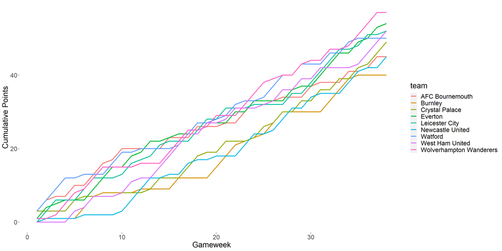